# Machine Learning Project

Shahram Sharaf

## Executive Summary

### Background

Using devices such as Jawbone Up, Nike FuelBand, and Fitbit it is now possible to collect a large amount of data about personal activity relatively inexpensively. These type of devices are part of the quantified self movement - a group of enthusiasts who take measurements about themselves regularly to improve their health, to find patterns in their behavior, or because they are tech geeks. One thing that people regularly do is quantify how much of a particular activity they do, but they rarely quantify how well they do it.

### Project

In this analysis, the data from accelerometers on the belt, forearm, arm, and dumbell of 6 participants is to be used to predict which of the 5 exercise classes were used.

Our analysis shows that a Random Forest analysis offers a predictive model with high accuracy. This model was used to predict the outcomes of the 20 cases in the test data set.

## Analysis

As the first step, required libraries are loaded. A random variable seed is also set in order to ensure the reproducibility of the analysis.

```r
library(dplyr)
library(caret)
library(rpart.plot)
set.seed (3624)
```

### Data Loading and Transformation

We first load and examine the data. Based on this examination, we conduct a few  
basic transformation of the data.

```r
setInternet2(TRUE)
train<-read.csv("https://d396qusza40orc.cloudfront.net/predmachlearn/pml-training.csv",
                as.is=TRUE, na.strings=c("", "NA"))
test<-read.csv("https://d396qusza40orc.cloudfront.net/predmachlearn/pml-testing.csv",
               as.is=TRUE, na.strings=c("","NA"))
```

Because it is smaller, the test data set is used to examine the data and create a tidy data set.

```r
summary(test)
head(test)
```

This examination shows that there are a number of fields for which all values are NA. As a result, these fields are not useful in a predictive model.  
Additionally, field identifiers such as the name of the subject and the time of the observation are not relevant to the purpose of this analysis. These fields are removed before modeling.

```r
colsna<-colnames(test[, apply(is.na(test), 2, all)])
train<-select(train, -one_of(colsna))
train<-train[,-(1:7)]
test<-select(test, -one_of(colsna))
test<-test[,-(1:7)]
```

The data is then preprocessed for improved model fit. Given the number of features in the set, modeling with high accuracy is expensive in terms of time and processing power. So, a number of preprocessing approaches were examined, including Principal Component Analysis. It turned out that using PCA to reduce the number of features while maintaining a high accuracy threshold did not significantly reduce the processing time. So, the data was preprocessed to scale and center the features.

```r
preProcValues <- preProcess(train[,-53], method = c("center", "scale"))
trainTransformed <- predict(preProcValues, train[,-53])
trainTransformed<-cbind(trainTransformed,"classe"=factor(train$classe))
testTransformed <- predict(preProcValues, test[,-53])
```

Another trade off in processing time and accuracy is in terms of the size of the training data set. Multiple training runs indicate that using even 25% of the training set can result in a high accuracy model. For the final report, the training set was split to two equal sets for the purposes of training and validation of the data.

```r
inTrain<-createDataPartition(y=trainTransformed$classe,p=0.5,list=FALSE)
training<-trainTransformed[inTrain,]
validation<-trainTransformed[-inTrain,]
```

The final training set is examined to ensure the proper distribution of the target outcome.

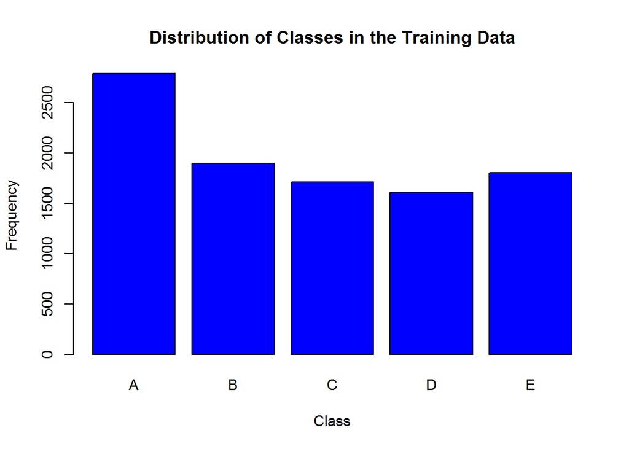

```r
plot(training$classe, col="blue",
     main="Distribution of Classes in the Training Data",
     xlab="Class", ylab="Frequency")
```

It appears that there is a large number of data points for each exercise type.

## Building the Model and Validation

Multiple modeling approaches were considered and examined. Two techniques are reported in this analysis. The first is a classification tree. The model is built and the classification tree is plotted.

```r
system.time(modelFit <- train(classe ~ ., method = "rpart", data = training))
```

```
##    user  system elapsed
##  105.55    0.66  106.54
```

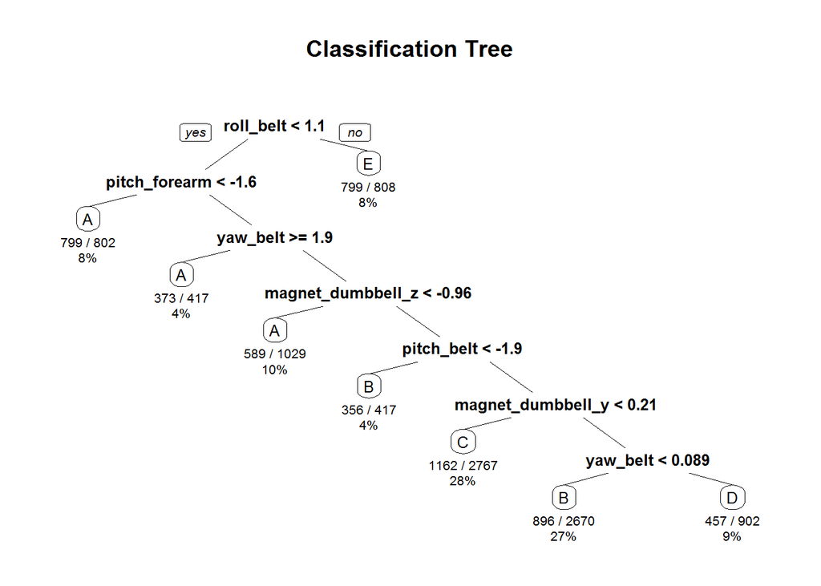

```r
#system.time(modelFit <- train(classe ~ ., method = "rf", data = training))
rpart.plot(modelFit$finalModel, main="Classification Tree", extra=102, under=TRUE, faclen=0)
```

The model is obviously very fast but it needs to be examined for accuracy using the validation data.

```r
confmtx <- confusionMatrix(validation$classe, predict(modelFit, validation))
confmtx
```

```
## Confusion Matrix and Statistics
##
##           Reference
## Prediction    A    B    C    D    E
##          A 1678  518  556   33    5
##          B  313 1230  327   28    0
##          C   43  228 1112  328    0
##          D   90  618  453  447    0
##          E   25  515  357   74  832
##
## Overall Statistics
##
##                Accuracy : 0.5402
##                  95% CI : (0.5302, 0.5501)
##     No Information Rate : 0.3169
##     P-Value [Acc > NIR] : < 2.2e-16
##
##                   Kappa : 0.422
##  Mcnemar's Test P-Value : < 2.2e-16
##
## Statistics by Class:
##
##                      Class: A Class: B Class: C Class: D Class: E
## Sensitivity            0.7808   0.3956   0.3964  0.49121  0.99403
## Specificity            0.8548   0.9003   0.9145  0.86955  0.89179
## Pos Pred Value         0.6014   0.6481   0.6499  0.27799  0.46145
## Neg Pred Value         0.9329   0.7625   0.7910  0.94355  0.99938
## Prevalence             0.2191   0.3169   0.2859  0.09276  0.08532
## Detection Rate         0.1710   0.1254   0.1134  0.04557  0.08481
## Detection Prevalence   0.2844   0.1935   0.1744  0.16391  0.18379
## Balanced Accuracy      0.8178   0.6480   0.6555  0.68038  0.94291
```

As indicated by the confusion matrix, this model has an overall accuracy of 54.02%

Another model is then built using the random forest technique.

```r
system.time(modelFit <- train(classe ~ ., method = "rf", data = training))
```

```
##    user  system elapsed
## 4955.95   27.77 5287.95
```

This model is much slower. We then examine its accuracy , again using the validation data.

```r
confmtx <- confusionMatrix(validation$classe, predict(modelFit, validation))
confmtx
```

```
## Confusion Matrix and Statistics
##
##           Reference
## Prediction    A    B    C    D    E
##          A 2781    7    0    0    2
##          B   22 1865   11    0    0
##          C    0   20 1686    5    0
##          D    0    0   17 1591    0
##          E    0    4    4    9 1786
##
## Overall Statistics
##
##                Accuracy : 0.9897
##                  95% CI : (0.9875, 0.9916)
##     No Information Rate : 0.2857
##     P-Value [Acc > NIR] : < 2.2e-16
##
##                   Kappa : 0.987
##  Mcnemar's Test P-Value : NA
##
## Statistics by Class:
##
##                      Class: A Class: B Class: C Class: D Class: E
## Sensitivity            0.9922   0.9836   0.9814   0.9913   0.9989
## Specificity            0.9987   0.9958   0.9969   0.9979   0.9979
## Pos Pred Value         0.9968   0.9826   0.9854   0.9894   0.9906
## Neg Pred Value         0.9969   0.9961   0.9960   0.9983   0.9998
## Prevalence             0.2857   0.1933   0.1751   0.1636   0.1823
## Detection Rate         0.2835   0.1901   0.1719   0.1622   0.1821
## Detection Prevalence   0.2844   0.1935   0.1744   0.1639   0.1838
## Balanced Accuracy      0.9954   0.9897   0.9891   0.9946   0.9984
```

As indicated by the confusion matrix, this model has an overall accuracy of 98.97%

## Conclusion

The random forest technique is much more effective in providing high accuracy predictions. This technique is applied to the test data for the final results.

```r
prediction<-predict(modelFit,testTransformed)
prediction
```

```
##  [1] B A B A A E D B A A B C B A E E A B B B
## Levels: A B C D E
```